# Intro to data visualization with ggplot2

Author

Affiliation

Brandon Le

Institute for Genome Biology  
Department of Botany and Plant Sciences

Published

October 30, 2025

In this session, we will work with data visualization using `ggplot2.` Although there are many systems in R for generating graphs, ggplot2 is the most versatile and elegant. We will use examples from the [R Graphics Cookbook](https://r-graphics.org).

> ggplot2 implements the **grammar of graphics**, a coherent system for describing and building graphs. With ggplot2, you can do more faster by learning one system and applying it in many places. [R4DS-Data Visualization](https://r4ds.had.co.nz/data-visualisation.html)

## Resources on ggplot2

- [The R Graphics Cookbook](http://www.cookbook-r.com/Graphs) by Winston Chang
- [Plotting Anything with ggplot2](https://youtu.be/h29g21z0a68) by Thomas Lin Pedersen (webinar)
- [R4DS-Data Visualization](https://r4ds.had.co.nz/data-visualisation.html) by Hadley Wickham & Garrett Grolemund
- [ggplot2: Elegant Graphics for Data Analysis](https://ggplot2-book.org/) is a more advanced and in-depth assessment of the theoretical underpinnings of ggplot2
- [Colorbrewer](https://colorbrewer2.org/) provide good recommendation for color selection

## Basic Syntax

**data**: data to plot  
**aes**: aesthetic mappings between variables in the data  
**geom**: layer describing how to render the observations (data)

```r
ggplot(data = data_file, aes(x = , y = )) + geom_layer

    geom_bar()
    geom_histogram()
    geom_density()
    geom_boxplot()
    geom_point() # scatter plots
    geom_pie()
```

## Layering Plots

We can layer multiple plots on top of each other. For example, if we want to plot histogram and density plots together, we use the ‘+’ sign to add additional plots.

```r
ggplot(data = data_file, aes(x = , y = )) +
    geom_histogram() +
    geom_density()
```

## Load required libraries

```r
library(ggplot2)
library(reshape2) # contains the tips data
```

## Dataset

We will be working with the `tips` dataset that’s part of the `reshape2` package.

The `tips` dataset contains information collected by a waiter about each tip received over a few months. It includes variables such as:

**total_bill:** The total bill amount in dollars.  
**tip**: The tip amount in dollars.  
**sex**: Gender of the bill payer (Male/Female).  
**smoker**: Whether there were smokers in the party (Yes/No).  
**day**: Day of the week (Thur, Fri, Sat, Sun).  
**time**: Time of day (Lunch/Dinner).  
**size**: Number of people in the party.

```r
head(tips)
```

```
  total_bill  tip    sex smoker day   time size
1      16.99 1.01 Female     No Sun Dinner    2
2      10.34 1.66   Male     No Sun Dinner    3
3      21.01 3.50   Male     No Sun Dinner    3
4      23.68 3.31   Male     No Sun Dinner    2
5      24.59 3.61 Female     No Sun Dinner    4
6      25.29 4.71   Male     No Sun Dinner    4
```

## Bar Graphs

### Basic bar graph

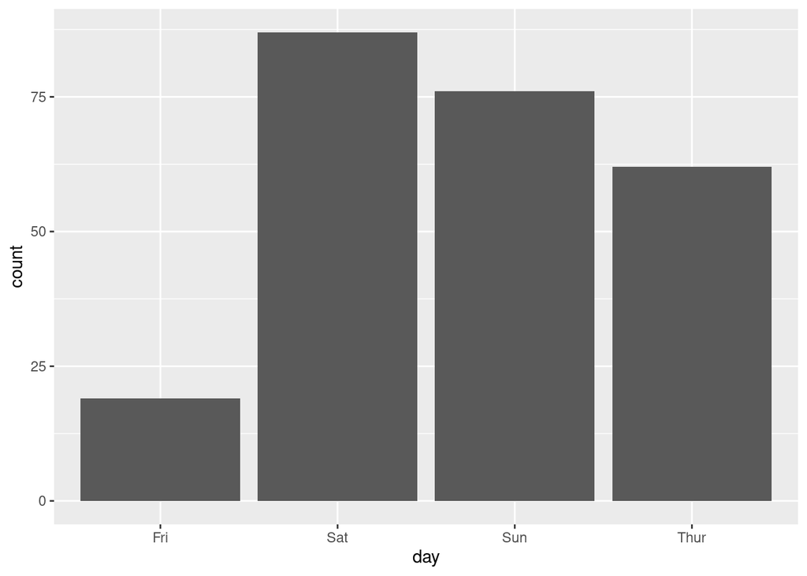

```r
ggplot(data=tips, aes(x=day)) +
    geom_bar(stat="count")
```

### Fill the bars

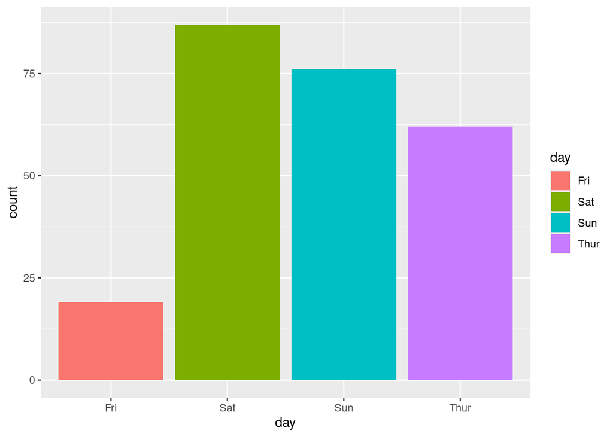

```r
ggplot(data=tips, aes(x=day, fill = day)) +
    geom_bar(stat="count")
```

### Add border color

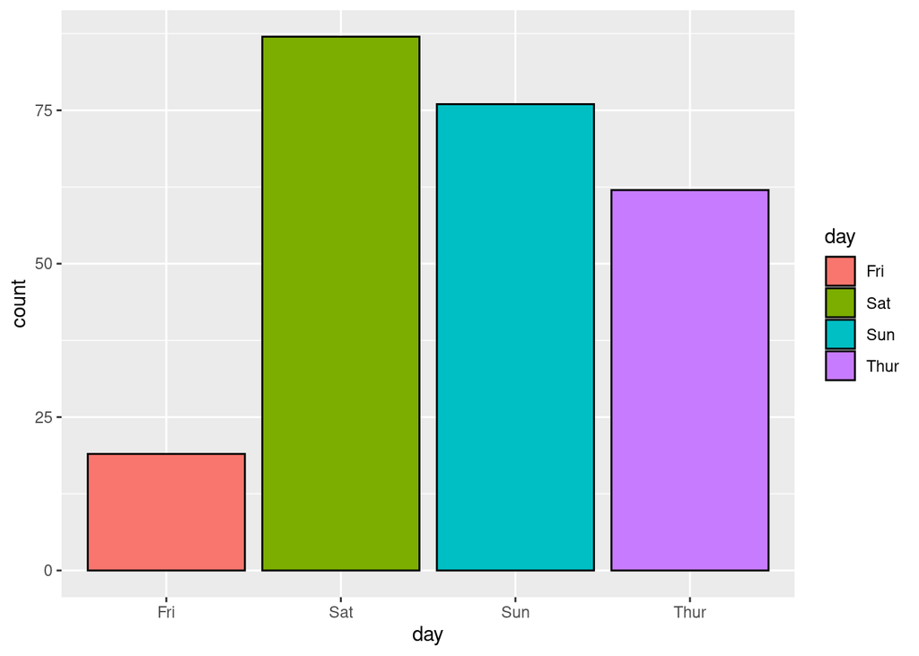

```r
ggplot(data=tips, aes(x=day, fill=day)) +
    geom_bar(color="black", stat="count")
```

### Reorder bars by day of the week

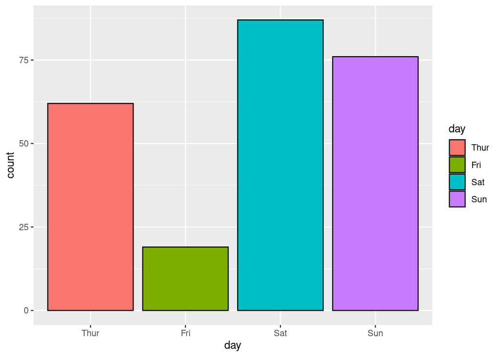

```r
tips$day <- factor(tips$day, levels = c("Thur", "Fri", "Sat", "Sun"))

ggplot(data=tips, aes(x=day, fill=day)) +
  geom_bar(color="black", stat="count")
```

### Remove the legend

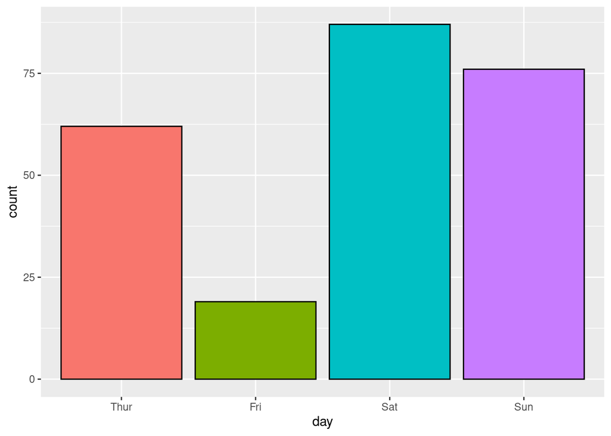

```r
ggplot(data=tips, aes(x=day, fill=day)) +
  geom_bar(color="black", stat="count") +

  guides(fill="none")
```

### Set colors manually

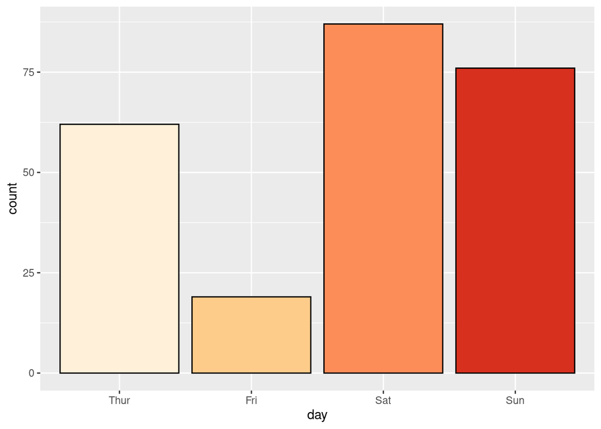

```r
ggplot(data=tips, aes(x=day, fill=day)) +
  geom_bar(color="black", stat="count")+
  guides(fill="none") +

  scale_fill_manual(values = c(
    "Thur" = "#fef0d9",
    "Fri" = "#fdcc8a",
    "Sat" = "#fc8d59",
    "Sun" = "#d7301f"
  ))
```

### Labels

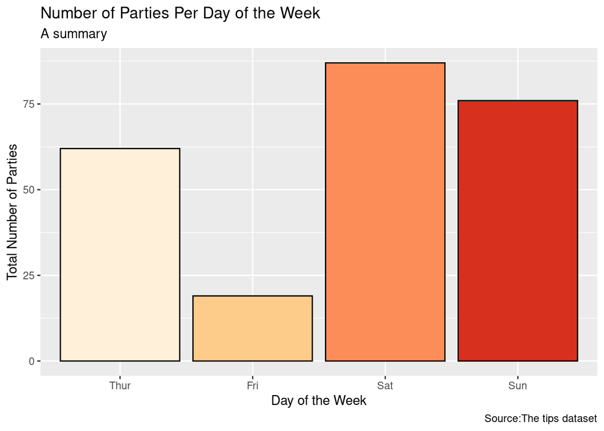

```r
ggplot(data=tips, aes(x=day, fill=day)) +
  geom_bar(color="black", stat="count")+
  guides(fill="none") +
  scale_fill_manual(values = c(
    "Thur" = "#fef0d9",
    "Fri" = "#fdcc8a",
    "Sat" = "#fc8d59",
    "Sun" = "#d7301f"
  )) +

  labs(title = "Number of Parties Per Day of the Week",
       caption = "Source:The tips dataset", subtitle = "A summary") +
  xlab("Day of the Week") +
  ylab("Total Number of Parties")
```

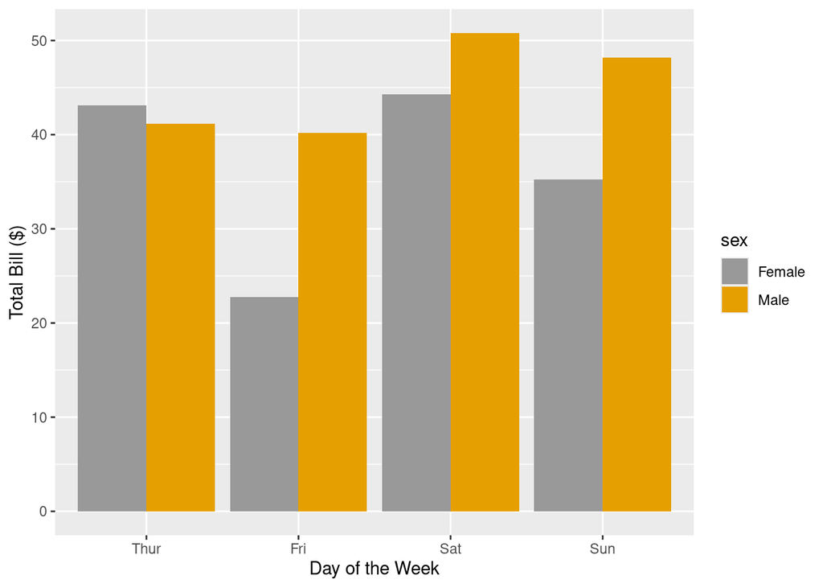

```r
ggplot(data=tips, aes(x=day, y= total_bill, fill=sex)) +
  geom_bar(stat="identity", position = position_dodge()) +
  scale_fill_manual(values = c(
    "Female" = "#999999",
    "Male" = "#E69F00"
  )) +
  xlab("Day of the Week") +
  ylab("Total Bill ($)")
```

## Distribution plots

### Sample dataset

```r
set.seed(1234)
dat <- data.frame(cond = factor(rep(c("A","B"), each=200)),
                   rating = c(rnorm(200),rnorm(200, mean=.8)))
# View first few rows
head(dat)
```

```
  cond     rating
1    A -1.2070657
2    A  0.2774292
3    A  1.0844412
4    A -2.3456977
5    A  0.4291247
6    A  0.5060559
```

## Histogram - Single Group

Basic histogram from the vector “rating”. Each bin is .5 wide.

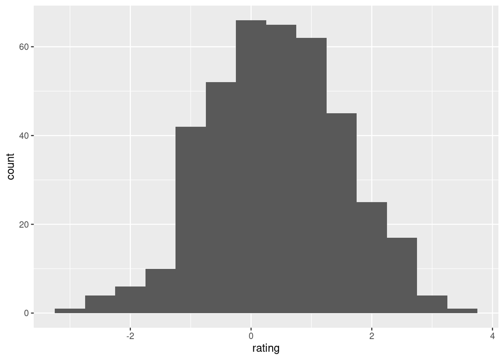

```r
ggplot(dat, aes(x=rating)) +
  geom_histogram(binwidth = 0.5)
```

### Border and fill colors

Border color = “white”  
Fill color = “black”

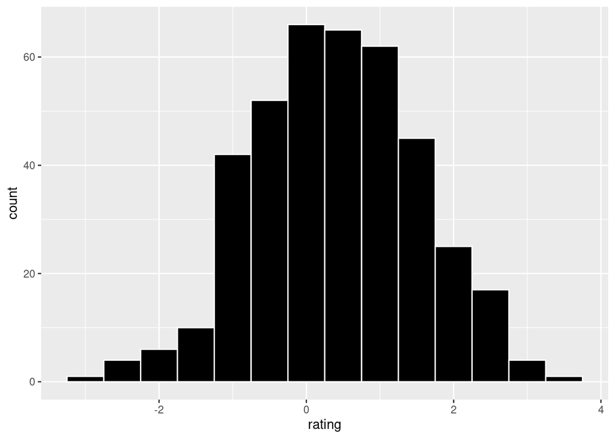

```r
ggplot(dat, aes(x=rating)) +
    geom_histogram(binwidth=.5, colour="white", fill="black")
```

## Density curve - Single Group

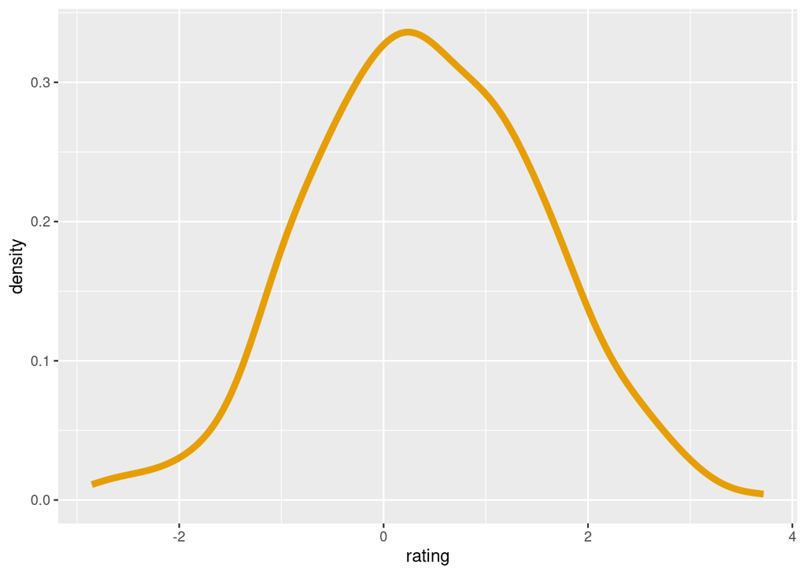

```r
ggplot(dat, aes(x=rating)) +
  geom_density(color = "#E69F00", linewidth = 2)
```

## Histogram & density plot overlay

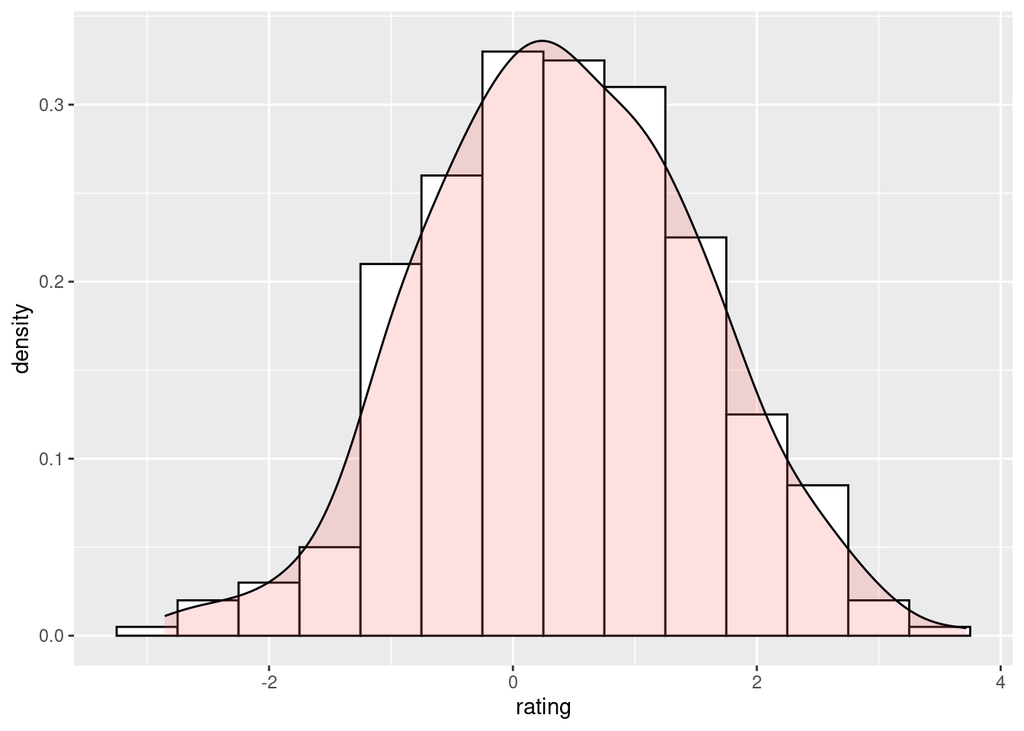

```r
ggplot(dat, aes(x=rating, y = after_stat(density))) +
    geom_histogram(binwidth=.5,
                   colour="black", fill="white") +
    geom_density(alpha=0.2, fill="#FF6666")  # Overlay with transparent density plot
```

## Histogram - Multiple Groups

### Overlaid histograms

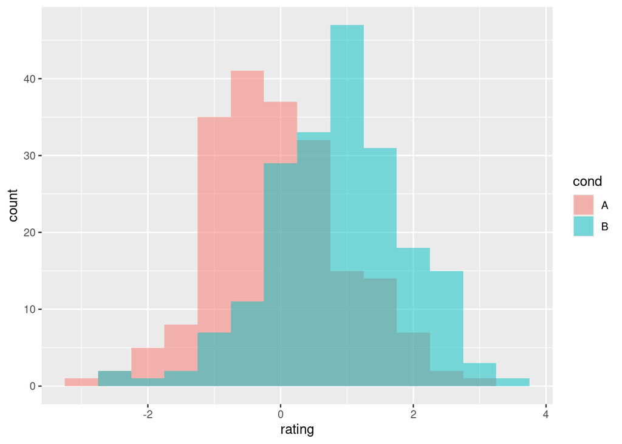

```r
ggplot(dat, aes(x=rating, fill=cond)) +
    geom_histogram(binwidth=.5, alpha=.5, position="identity")
```

### Interleaved histograms

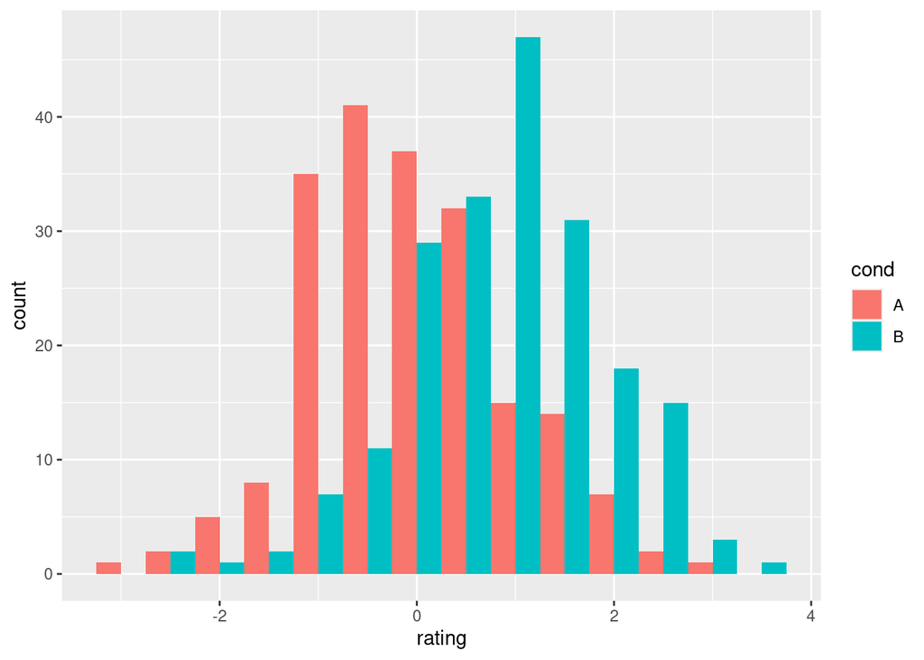

```r
ggplot(dat, aes(x=rating, fill=cond)) +
    geom_histogram(binwidth=.5, position="dodge")
```

## Density curves - Multiple Groups

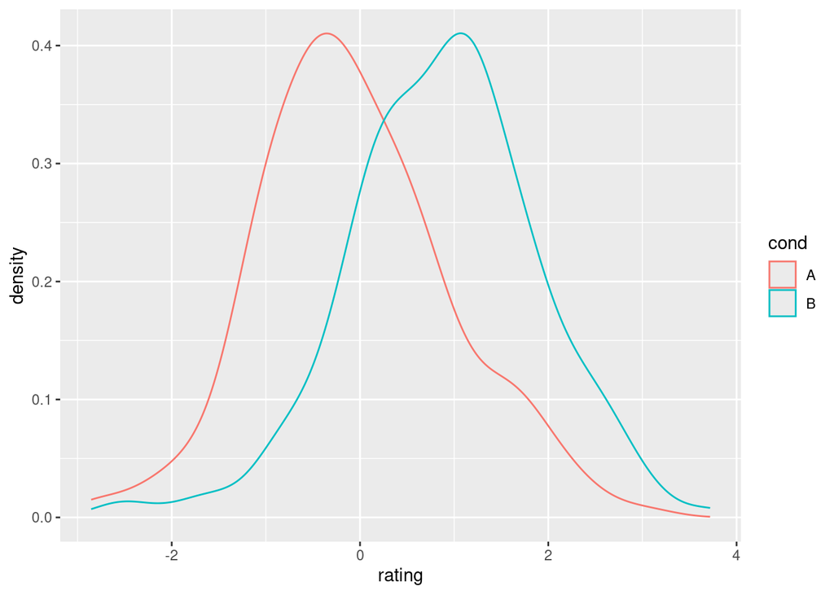

```r
ggplot(dat, aes(x=rating, colour=cond)) +
  geom_density()
```

## Density curves with transparency

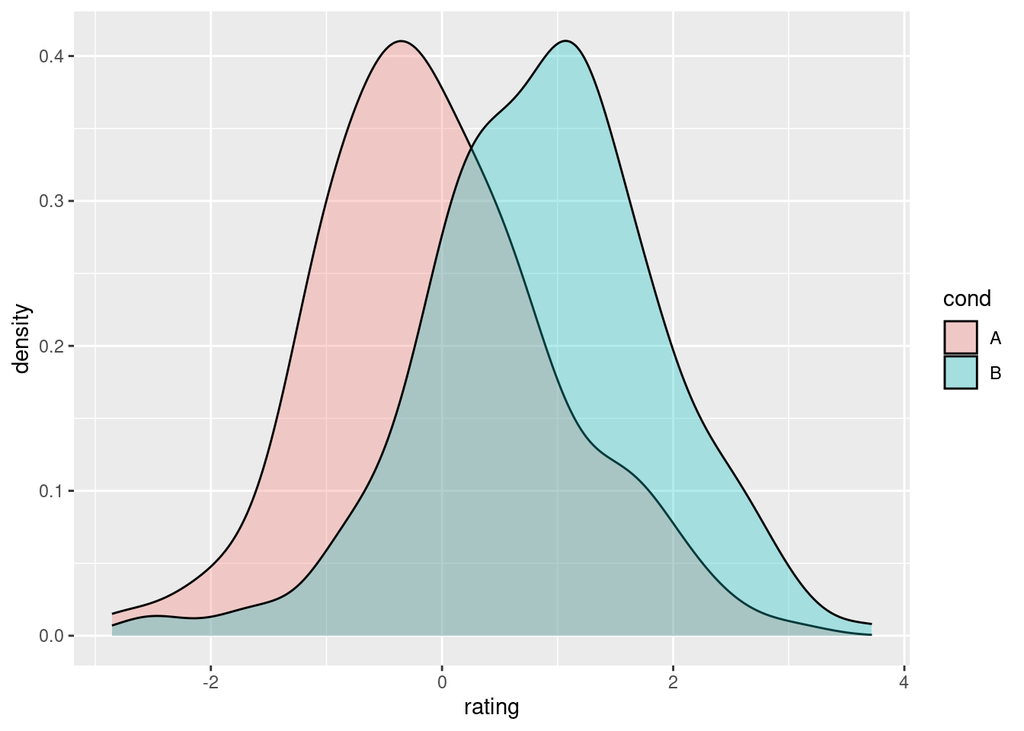

```r
# Density plots with semi-transparent fill
ggplot(dat, aes(x=rating, fill=cond)) +
  geom_density(alpha=.3)
```

## Empirical cumulative distribution function

### CDF with points

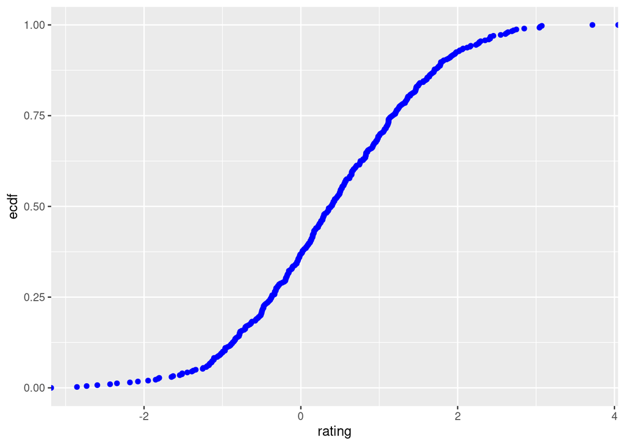

```r
ggplot(dat, aes(rating)) +
  stat_ecdf(geom = "point", color = "blue")
```

### CDF with steps

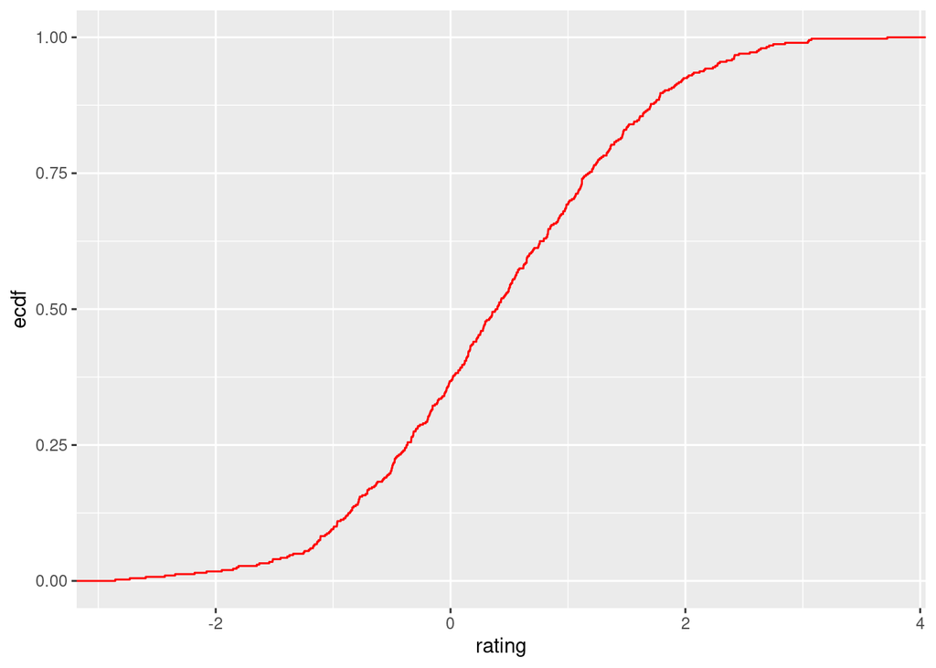

```r
ggplot(dat, aes(rating)) +
  stat_ecdf(geom = "step", color = "red")
```

### CDF with smoothing

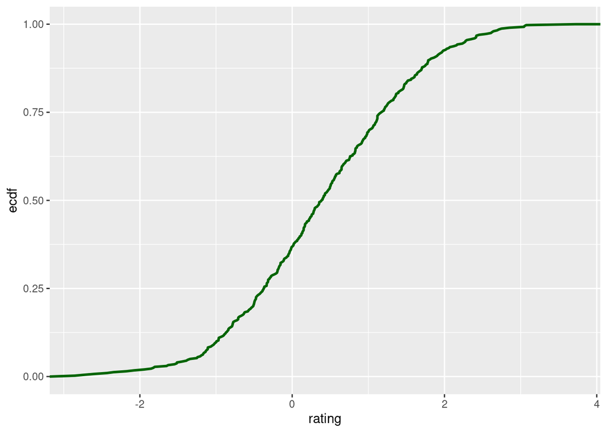

```r
ggplot(dat, aes(rating)) +
  stat_ecdf(geom = "smooth", color = "darkgreen")
```

### Multiple ECDFs based on condition

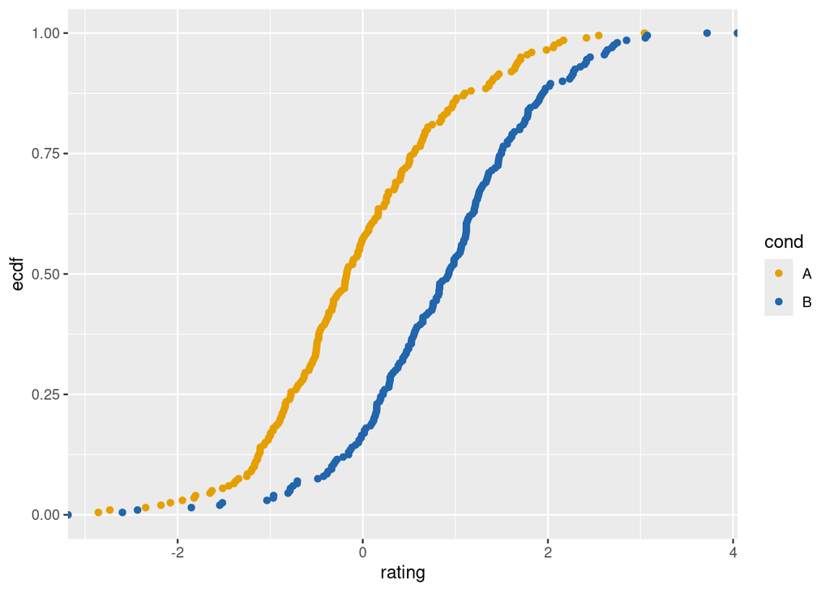

```r
ggplot(dat, aes(rating, color = cond)) +
  stat_ecdf(geom = "point") +
  scale_color_manual(values = c(
    "A" = "#E69F00",
    "B" = "#2166ac"
  ))
```

## Box plots

### Basic box plot

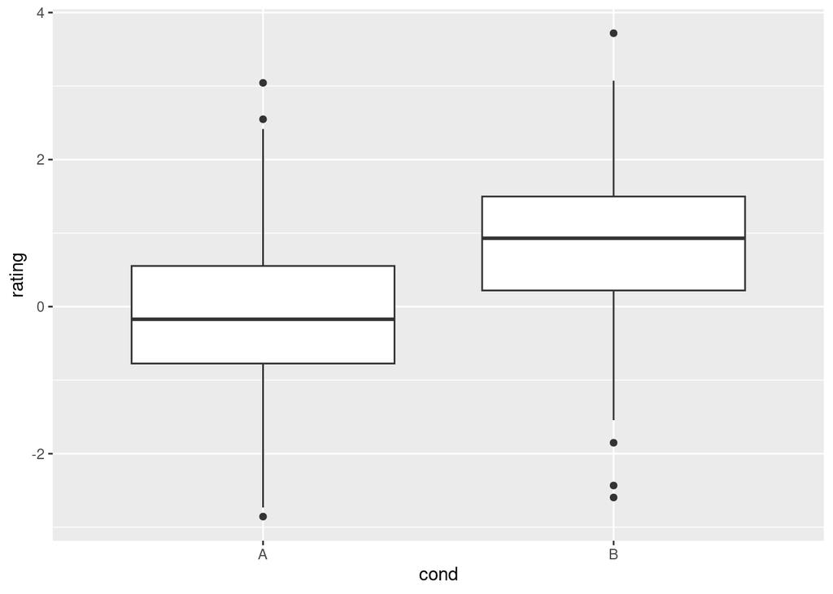

```r
# A basic box plot
ggplot(dat, aes(x=cond, y=rating)) +
  geom_boxplot()
```

### Color by conditions

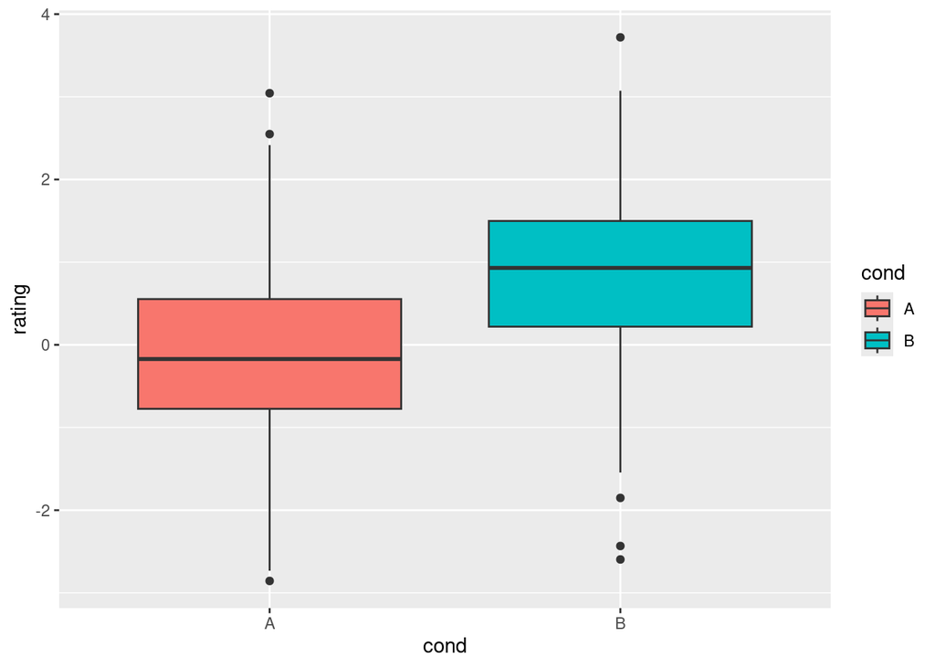

```r
ggplot(dat, aes(x=cond, y=rating, fill=cond)) +
  geom_boxplot()
```

### Add data points

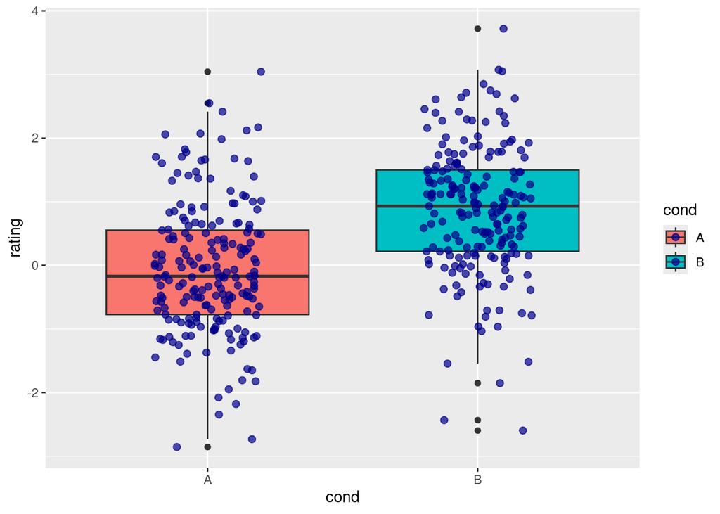

```r
ggplot(dat, aes(x=cond, y=rating, fill=cond)) +
  geom_boxplot() +
  geom_jitter(width = 0.2, alpha = 0.7, size = 2, color = "darkblue")
```

### Flip axes

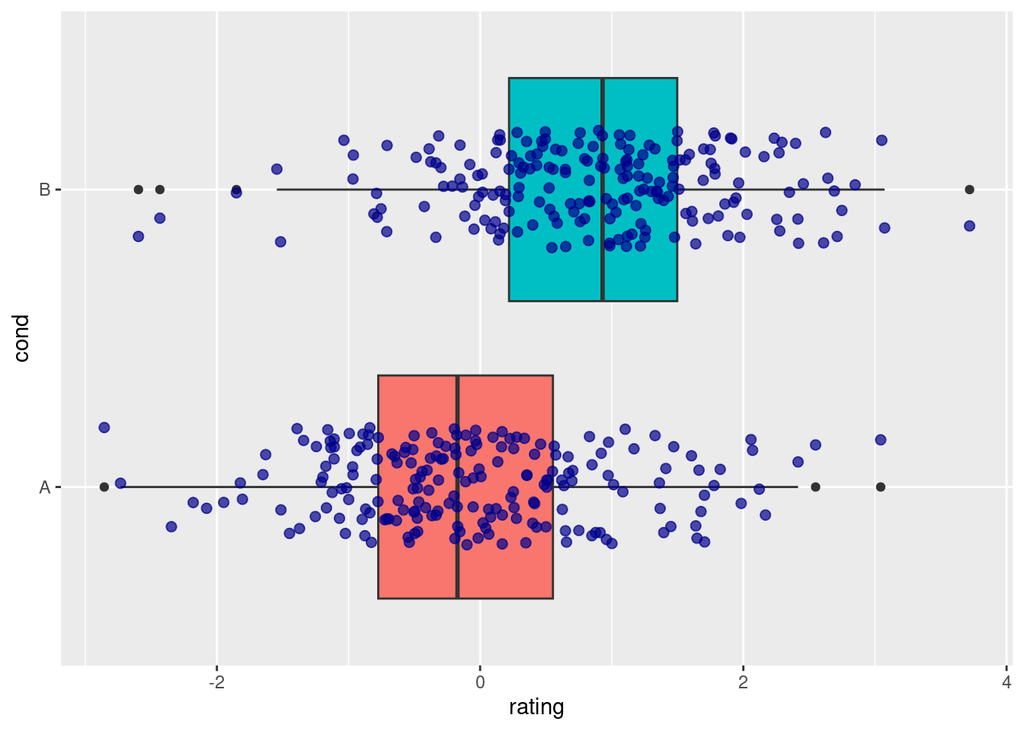

```r
ggplot(dat, aes(x=cond, y=rating, fill=cond)) +
  geom_boxplot() +
  geom_jitter(width = 0.2, alpha = 0.7, size = 2, color = "darkblue") +

  guides(fill="none") +
  coord_flip()
```